# Procesamiento del Lenguaje Natural

## Dataset: The Multilingual Amazon Reviews Corpus

Créditos por utilización de datos:  
Justifying recommendations using distantly-labeled reviews and fined-grained aspects  
Jianmo Ni, Jiacheng Li, Julian McAuley  
[Empirical Methods in Natural Language Processing (EMNLP), 2019.](https://cseweb.ucsd.edu//~jmcauley/pdfs/emnlp19a.pdf)

### Exploración de datos y Procesamiento del Lenguaje Natural

En este informe se trabaja sobre las críticas de productos de amazon y se desarrolla un modelo que asigna la cantidad de estrellas correspondiente a la review. Se divide en tres partes: primero, se hace una pequeña exploración de los datos. Luego se implementa ya el modelo adecuado elegido y finalmente se presentan recomendaciones para mejorar el trabajo realizado.

### Parte A: Exploración de datos

En esta parte nos dedicaremos a hacer una pequeña exploración de datos. Notaremos, cuáles son las palabras más utilizadas para las críticas positivas, negativas y neutras?

```python
import itertools

import numpy as np
import pandas as pd

import matplotlib.pyplot as plt
import seaborn as sns
sns.set()

import nltk

# Esto sirve para configurar NLTK. La primera vez puede tardar un poco
nltk.download('punkt')
nltk.download('stopwords')
```

```
True
```

```python
dataset = pd.read_json('dataset_es_train.json', lines= True)
dataset.head()
```

|  | review_id | product_id | reviewer_id | stars | review_body | review_title | language | product_category |
| --- | --- | --- | --- | --- | --- | --- | --- | --- |
| 0 | es_0491108 | product_es_0296024 | reviewer_es_0999081 | 1 | Nada bueno se me fue ka pantalla en menos de 8... | television Nevir | es | electronics |
| 1 | es_0869872 | product_es_0922286 | reviewer_es_0216771 | 1 | Horrible, nos tuvimos que comprar otro porque ... | Dinero tirado a la basura con esta compra | es | electronics |
| 2 | es_0811721 | product_es_0474543 | reviewer_es_0929213 | 1 | Te obligan a comprar dos unidades y te llega s... | solo llega una unidad cuando te obligan a comp... | es | drugstore |
| 3 | es_0359921 | product_es_0656090 | reviewer_es_0224702 | 1 | No entro en descalificar al vendedor, solo pue... | PRODUCTO NO RECIBIDO. | es | wireless |
| 4 | es_0068940 | product_es_0662544 | reviewer_es_0224827 | 1 | Llega tarde y co la talla equivocada | Devuelto | es | shoes |

```python
dataset.shape
```

```
(200000, 8)
```

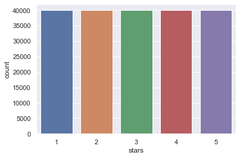

```python
sns.countplot(x=dataset.stars)
plt.show()
```

Notamos que hay una distribución uniforme de las calificaciones en el dataset, es decir, hay igual cantidad de críticas de tantas estrellas para trabajar. Esto influirá luego en la métrica a elegir para el modelo de machine learning.

```python
dataset.columns
```

```
Index(['review_id', 'product_id', 'reviewer_id', 'stars', 'review_body',
       'review_title', 'language', 'product_category'],
      dtype='object')
```

Importamos las stopwords y las visualizamos:

```python
stopwords = nltk.corpus.stopwords.words('spanish')
stopwords = [palabra for palabra in stopwords if 'not' not in palabra]
stopwords
```

[output not shown]

[output cut: 258 more lines]

```
 'tuvieras',
 'tuviéramos',
 'tuvierais',
 'tuvieran',
 'tuviese',
 'tuvieses',
 'tuviésemos',
 'tuvieseis',
 'tuviesen',
 'teniendo',
 'tenido',
 'tenida',
 'tenidos',
 'tenidas',
 'tened']
```

Ahora dividimos el dataset en 3 partes, una con críticas que se consideran positivas, con 4 o 5 estrellas; otra con críticas negativas, con 1 o 2 estrellas; y por último las neutrales, con calificación de 3 estrellas. Les sacamos las stopwords y analizamos cuales son las palabras más usadas para tales críticas.

```python
dataset_positivo = dataset[dataset.stars>3]
```

```python
filtrar = []
if True:
    filtrar.append("u")
    filtrar.append("new")
```

```python
dataset_positivo= dataset_positivo.applymap(lambda s:s.lower() if type(s) == str else s) #ponemos todo en minúsculas
```

```python
reviews_positivas = []
for i in range(dataset_positivo.shape[0]):
    review = dataset_positivo.iloc[i].review_body
    review = nltk.tokenize.RegexpTokenizer("[\w]+").tokenize(review)
    review = [word for word in review if word not in stopwords]
    review = [word for word in review if word not in filtrar]

    reviews_positivas.append(review)
```

```python
reviews_positivas = list(itertools.chain(*reviews_positivas))
reviews_positivas[0:10]
```

```
['buena',
 'pinta',
 'veremos',
 'resultado',
 'entrega',
 'rápida',
 'siempre',
 'falta',
 'factura',
 'bien']
```

```python
freq_positiva = nltk.FreqDist(reviews_positivas)
freq_positiva
```

```
FreqDist({'bien': 23539, 'calidad': 15739, 'buena': 13130, 'precio': 12876, 'producto': 8791, 'buen': 7999, 'perfecto': 7368, 'si': 7365, 'bastante': 6061, 'perfectamente': 4842, ...})
```

```python
df_positivo = pd.DataFrame(list(freq_positiva.items()), columns = ["Palabra","Frecuencia"])
df_positivo.head()
```

|  | Palabra | Frecuencia |
| --- | --- | --- |
| 0 | buena | 13130 |
| 1 | pinta | 353 |
| 2 | veremos | 239 |
| 3 | resultado | 804 |
| 4 | entrega | 1532 |

```python
df_positivo.sort_values('Frecuencia',ascending=False, inplace = True)
df_positivo.head()
```

|  | Palabra | Frecuencia |
| --- | --- | --- |
| 9 | bien | 23539 |
| 26 | calidad | 15739 |
| 0 | buena | 13130 |
| 107 | precio | 12876 |
| 154 | producto | 8791 |

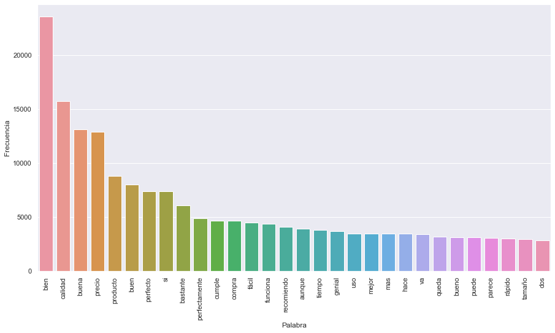

```python
plt.figure(figsize = (15,8))
plot = sns.barplot(x  = df_positivo.iloc[:30].Palabra, y = df_positivo.iloc[:30].Frecuencia)
for item in plot.get_xticklabels():
    item.set_rotation(90)
plt.show()
```

Vemos que las palabras más utilizadas son bien, calidad, buena, precio, etc. Ahora hacemos lo mismo para las críticas negativas.

```python
dataset_negativo = dataset[dataset.stars<3]
```

```python
dataset_negativo= dataset_negativo.applymap(lambda s:s.lower() if type(s) == str else s)
```

```python
reviews_negativas = []
for i in range(dataset_negativo.shape[0]):
    review = dataset_negativo.iloc[i].review_body
    review = nltk.tokenize.RegexpTokenizer("[\w]+").tokenize(review)
    review = [word for word in review if word not in stopwords]
    review = [word for word in review if word not in filtrar]

    reviews_negativas.append(review)
```

```python
reviews_negativas = list(itertools.chain(*reviews_negativas))
reviews_negativas[0:10]
```

```
['bueno',
 'ka',
 'pantalla',
 'menos',
 '8',
 'meses',
 'recibido',
 'respuesta',
 'fabricante',
 'horrible']
```

```python
freq_negativa = nltk.FreqDist(reviews_negativas)
freq_negativa
```

```
FreqDist({'bien': 14075, 'producto': 11870, 'si': 11318, 'calidad': 10223, 'dos': 6590, 'mal': 5344, 'solo': 4922, 'funciona': 4710, 'precio': 4697, 'llegado': 4588, ...})
```

```python
df_negativo = pd.DataFrame(list(freq_negativa.items()), columns = ["Palabra","Frecuencia"])
df_negativo.head()
```

|  | Palabra | Frecuencia |
| --- | --- | --- |
| 0 | bueno | 1905 |
| 1 | ka | 11 |
| 2 | pantalla | 3806 |
| 3 | menos | 3530 |
| 4 | 8 | 585 |

```python
df_negativo.sort_values('Frecuencia',ascending=False, inplace = True)
df_negativo.head()
```

|  | Palabra | Frecuencia |
| --- | --- | --- |
| 98 | bien | 14075 |
| 36 | producto | 11870 |
| 175 | si | 11318 |
| 68 | calidad | 10223 |
| 19 | dos | 6590 |

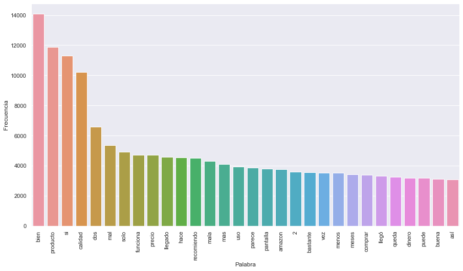

```python
plt.figure(figsize = (15,8))
plot = sns.barplot(x  = df_negativo.iloc[:30].Palabra, y = df_negativo.iloc[:30].Frecuencia)
for item in plot.get_xticklabels():
    item.set_rotation(90)
plt.show()
```

Por último, realizamos lo mismo para las críticas de 3 estrellas.

```python
dataset_neutro = dataset[dataset.stars==3]
```

```python
dataset_neutro= dataset_neutro.applymap(lambda s:s.lower() if type(s) == str else s)
```

```python
reviews_neutras = []
for i in range(dataset_neutro.shape[0]):
    review = dataset_neutro.iloc[i].review_body
    review = nltk.tokenize.RegexpTokenizer("[\w]+").tokenize(review)
    review = [word for word in review if word not in stopwords]
    review = [word for word in review if word not in filtrar]

    reviews_neutras.append(review)
```

```python
reviews_neutras = list(itertools.chain(*reviews_neutras))
reviews_neutras[0:10]
```

```
['cabe',
 'bien',
 'móvil',
 '5',
 '5',
 'cumple',
 'función',
 'hecha',
 'menos',
 'pequeño']
```

```python
freq_neutro = nltk.FreqDist(reviews_neutras)
freq_neutro
```

```
FreqDist({'bien': 13948, 'si': 6517, 'calidad': 5967, 'precio': 5376, 'producto': 3973, 'bastante': 3299, 'buena': 3223, 'aunque': 2882, 'mas': 2588, 'mal': 2242, ...})
```

```python
df_neutro = pd.DataFrame(list(freq_neutro.items()), columns = ["Palabra","Frecuencia"])
df_neutro.head()
```

|  | Palabra | Frecuencia |
| --- | --- | --- |
| 0 | cabe | 176 |
| 1 | bien | 13948 |
| 2 | móvil | 758 |
| 3 | 5 | 685 |
| 4 | cumple | 1864 |

```python
df_neutro.sort_values('Frecuencia',ascending=False, inplace = True)
df_neutro.head()
```

|  | Palabra | Frecuencia |
| --- | --- | --- |
| 1 | bien | 13948 |
| 52 | si | 6517 |
| 131 | calidad | 5967 |
| 120 | precio | 5376 |
| 85 | producto | 3973 |

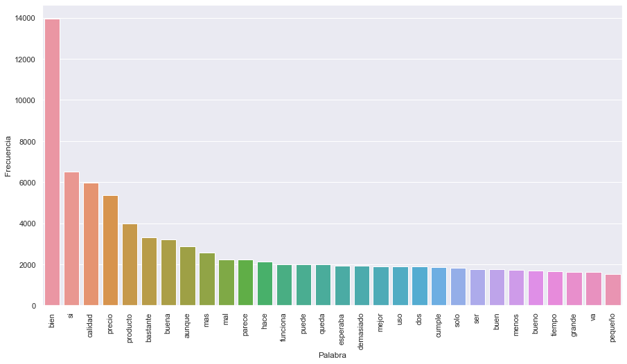

```python
plt.figure(figsize = (15,8))
plot = sns.barplot(x  = df_neutro.iloc[:30].Palabra, y = df_neutro.iloc[:30].Frecuencia)
for item in plot.get_xticklabels():
    item.set_rotation(90)
plt.show()
```

Vemos que mayoritariamente utilizan palabras parecidas, aunque algunas van variando. Como por ejemplo la palabra mal o mala no aparece en las críticas positivas, la palabra aunque aparece en las críticas neutras.

### Parte B: Modelo de Machine Learning

Ahora aplicamos stemming al dataset entero y aplicamos 2 modelos, uno que utilizaremos de benchmark (naive bayes) y un random forest.

```python
df_train = pd.read_json('dataset_es_train.json', lines= True)
df_test = pd.read_json('dataset_es_test.json', lines= True)
df_dev= pd.read_json('dataset_es_dev.json', lines= True)
```

```python
dataset_train=pd.concat([df_train.review_body,df_train.stars],axis=1)
dataset_train.dropna(axis=0,inplace=True)  # Si hay alguna nan, tiramos esa instancia
dataset_train.head()

dataset_test=pd.concat([df_test.review_body,df_test.stars],axis=1)
dataset_test.dropna(axis=0,inplace=True)  # Si hay alguna nan, tiramos esa instancia
dataset_test.head()

dataset_dev=pd.concat([df_dev.review_body,df_dev.stars],axis=1)
dataset_dev.dropna(axis=0,inplace=True)  # Si hay alguna nan, tiramos esa instancia
dataset_dev.head(4000)
```

|  | review_body | stars |
| --- | --- | --- |
| 0 | Malisimo, muy grande demasiado aparatoso y mal... | 1 |
| 1 | No he recibido el pedido no la devolución | 1 |
| 2 | Tengo que buscar otro sistema, este no funcion... | 1 |
| 3 | Utilicé las brocas de menor diámetro y se me d... | 1 |
| 4 | No me gusta su olor a viejo y aspecto malo | 1 |
| ... | ... | ... |
| 3995 | Los estoy usando para hacer saco en casa, van ... | 4 |
| 3996 | Lo del antirrobo es lo que no entiendo me gust... | 4 |
| 3997 | Queda muy bien en la cama yo se lo regale a mi... | 4 |
| 3998 | Se trata de un producto cómodo, tiene gran cal... | 4 |
| 3999 | Un buen regalo para bebés, lleno de colores, u... | 4 |

4000 rows × 2 columns

```python
import re

# Importamos la función que nos permite Stemmizar de nltk y definimos el stemmer
from nltk.stem import SnowballStemmer
stemmer = SnowballStemmer('spanish')

# Traemos nuevamente las stopwords
stopwords = nltk.corpus.stopwords.words('spanish')
```

```python
# Recorremos todos los titulos y le vamos aplicando la Normalizacion y luega el Stemming a cada uno
review_list_train=[]
for review_train in dataset_train.review_body:
    # Vamos a reemplzar los caracteres que no sean leras por espacios
    review_train=re.sub("[^a-zA-Z]"," ",str(review_train))
    # Pasamos todo a minúsculas
    review_train=review_train.lower()
    # Tokenizamos para separar las palabras del titular
    review_train=nltk.word_tokenize(review_train)
    # Eliminamos las palabras de menos de 3 letras
    review_train = [palabra for palabra in review_train if len(palabra)>3]
    # Sacamos las Stopwords
    review_train = [palabra for palabra in review_train if not palabra in stopwords]

    ## Hasta acá Normalizamos, ahora a stemmizar

    # Aplicamos la funcion para buscar la raiz de las palabras
    review_train=[stemmer.stem(palabra) for palabra in review_train]
    # Por ultimo volvemos a unir el titular
    review_train=" ".join(review_train)

    # Vamos armando una lista con todos los titulares
    review_list_train.append(review_train)
    #dataset["titular_normalizado"] = titular_list
#___________________________________________________________________________________________
review_list_test=[]
for review_test in dataset_test.review_body:
    review_test=re.sub("[^a-zA-Z]"," ",str(review_test))
    review_test=review_test.lower()
    review_test=nltk.word_tokenize(review_test)
    review_test = [palabra for palabra in review_test if len(palabra)>3]
    review_test = [palabra for palabra in review_test if not palabra in stopwords]

    review_test=[stemmer.stem(palabra) for palabra in review_test]
    review_test=" ".join(review_test)

    review_list_test.append(review_test)
#___________________________________________________________________________________________
review_list_dev=[]
for review_dev in dataset_dev.review_body:
    review_dev=re.sub("[^a-zA-Z]"," ",str(review_dev))
    review_dev=review_dev.lower()
    review_dev=nltk.word_tokenize(review_dev)
    review_dev = [palabra for palabra in review_dev if len(palabra)>3]
    review_dev = [palabra for palabra in review_dev if not palabra in stopwords]

    review_dev=[stemmer.stem(palabra) for palabra in review_dev]
    review_dev=" ".join(review_dev)

    review_list_dev.append(review_dev)
#___________________________________________________________________________________________
```

```python
dataset_train["review_stem"] = review_list_train
dataset_test["review_stem"] = review_list_test
dataset_dev["review_stem"] = review_list_dev
```

```python
dataset_stem_train=pd.concat([dataset_train.review_stem,dataset_train.stars],axis=1)
dataset_stem_train.dropna(axis=0,inplace=True)

dataset_stem_test=pd.concat([dataset_test.review_stem,dataset_test.stars],axis=1)
dataset_stem_test.dropna(axis=0,inplace=True)

dataset_stem_dev=pd.concat([dataset_dev.review_stem,dataset_dev.stars],axis=1)
dataset_stem_dev.dropna(axis=0,inplace=True)

dataset_stem_dev.head()
```

|  | review_stem | stars |
| --- | --- | --- |
| 0 | malisim grand demasi aparat protector pantall | 1 |
| 1 | recib ped devoluci | 1 |
| 2 | busc sistem funcion bien abrazader llev agarr ... | 1 |
| 3 | utilic broc menor metr dobl vari mantequill ha... | 1 |
| 4 | gust olor viej aspect mal | 1 |

```python
list_reviews_train = list(dataset_stem_train['review_stem'].values)
stars_train = dataset_stem_train['stars'].values

list_reviews_test = list(dataset_stem_test['review_stem'].values)
stars_test = dataset_stem_test['stars'].values

list_reviews_dev = list(dataset_stem_dev['review_stem'].values)
stars_dev = dataset_stem_dev['stars'].values
```

```python
from sklearn.feature_extraction.text import CountVectorizer

# Usaremos solo las 1000 palabras con mas frecuencia en todo el corpus para generar los vectores
max_features=1000

# Es decir que cada instancia tendrá 1000 features
cou_vec_train=CountVectorizer(max_features=max_features, stop_words=stopwords)
cou_vec_test=CountVectorizer(max_features=max_features, stop_words=stopwords)
cou_vec_dev=CountVectorizer(max_features=max_features, stop_words=stopwords)
```

```python
matriz_reviews_train = cou_vec_train.fit_transform(list_reviews_train)
matriz_reviews_test = cou_vec_test.fit_transform(list_reviews_test)
matriz_reviews_dev = cou_vec_dev.fit_transform(list_reviews_dev)

# Tomamos las palabras
all_words_train = cou_vec_train.get_feature_names()
all_words_test = cou_vec_test.get_feature_names()
all_words_dev = cou_vec_dev.get_feature_names()


# Vizualizamos las 50 palabras mas usadas
print("50 palabras mas usadas: ",all_words_train[0:50])
print("50 palabras mas usadas: ",all_words_test[0:50])
print("50 palabras mas usadas: ",all_words_dev[0:50])
```

```
50 palabras mas usadas:  ['abaj', 'abiert', 'abre', 'abrir', 'abrirl', 'absolut', 'acab', 'accesori', 'aceit', 'acept', 'acer', 'aciert', 'acolch', 'aconsej', 'acopl', 'acord', 'acostumbr', 'activ', 'actualiz', 'adapt', 'adecu', 'adem', 'adhes', 'adult', 'agarr', 'agrad', 'agradec', 'agu', 'aguant',…
50 palabras mas usadas:  ['abaj', 'abiert', 'abre', 'abrir', 'abrirl', 'absolut', 'acab', 'accesori', 'aceit', 'acept', 'acer', 'aciert', 'acolch', 'aconsej', 'acopl', 'acord', 'acostumbr', 'activ', 'actualiz', 'adapt', 'adecu', 'adem', 'adhes', 'adjunt', 'adult', 'afil', 'agarr', 'agrad', 'agradec'…
50 palabras mas usadas:  ['abaj', 'abiert', 'abre', 'abrir', 'abrirl', 'absolut', 'acab', 'accesori', 'aceit', 'acept', 'acert', 'aconsej', 'acopl', 'acord', 'activ', 'adapt', 'adecu', 'adem', 'adhes', 'adjunt', 'adult', 'afil', 'agarr', 'agrad', 'agradec', 'agu', 'aguant', 'agujer', 'ahor', 'ahorr'…
```

```python
X_train = matriz_reviews_train.toarray()
y_train = stars_train

X_test = matriz_reviews_test.toarray()
y_test = stars_test

X_dev = matriz_reviews_dev.toarray()
y_dev = stars_dev
```

Aplicamos un modelo naive bayes. Utilizamos como métrica el accuracy ya que es la mejor métrica a utilizar cuando la distribución del target es uniforme (como vimos anteriormente, había igual cantidad de opiniones para tantas estrellas).

```python
from sklearn.naive_bayes import MultinomialNB
nb = MultinomialNB()
nb.fit(X_train,y_train)
print("acc : ", nb.score(X_test,y_test))
```

```
acc :  0.2566
```

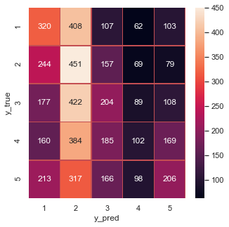

```python
from sklearn.metrics import confusion_matrix

def confusion(y_test,y_pred):
    names=["1","2","3","4","5"]
    cm=confusion_matrix(y_test,y_pred)
    f,ax=plt.subplots(figsize=(5,5))
    sns.heatmap(cm,annot=True,linewidth=.5,linecolor="r",fmt=".0f",ax=ax)
    plt.xlabel("y_pred")
    plt.ylabel("y_true")
    ax.set_xticklabels(names)
    ax.set_yticklabels(names)
    plt.show()

    return
y_pred=nb.predict(X_test)
confusion(y_test,y_pred)
```

Aplicamos ahora un modelor random forest, y optimizamos los hiperparámetros con un random search.

```python
from sklearn.ensemble import RandomForestClassifier
from sklearn.metrics import confusion_matrix


rf = RandomForestClassifier(n_estimators = 79, random_state=42, max_depth=18)
rf.fit(X_train,y_train)
print("acc: ",rf.score(X_test,y_test))
```

```
acc:  0.2342
```

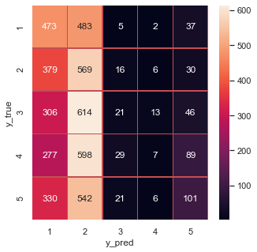

```python
y_pred=rf.predict(X_test)
confusion(y_test,y_pred)
```

Nuevamente vemos que el modelo performa mejor para las críticas negativas que para las positivas. Vemos que el modelo performa peor que el modelo benchmark. Aunque lo hizo mucho mejor para las críticas negativas. Veremos luego qué palabras utilizó para tomar las decisiones.

```python
import scipy as sp

param_dist = {'n_estimators':sp.stats.randint(50, 150),
              'max_depth':sp.stats.randint(1,20)}
```

```python
from sklearn.model_selection import RandomizedSearchCV
model = RandomizedSearchCV(rf, param_dist,n_iter=100, random_state=0, cv=5)

model.fit(X_dev, y_dev)

print("Mejores parametros: "+str(model.best_params_))
print("Mejor Score: "+str(model.best_score_)+'\n')

scores = pd.DataFrame(model.cv_results_)
scores
```

```
Mejores parametros: {'max_depth': 18, 'n_estimators': 79}
Mejor Score: 0.395
```

|  | mean_fit_time | std_fit_time | mean_score_time | std_score_time | param_max_depth | param_n_estimators | params | split0_test_score | split1_test_score | split2_test_score | split3_test_score | split4_test_score | mean_test_score | std_test_score | rank_test_score |
| --- | --- | --- | --- | --- | --- | --- | --- | --- | --- | --- | --- | --- | --- | --- | --- |
| 0 | 2.701039 | 0.325665 | 0.072816 | 0.018378 | 13 | 97 | {'max_depth': 13, 'n_estimators': 97} | 0.392 | 0.390 | 0.388 | 0.387 | 0.365 | 0.3844 | 0.009851 | 33 |
| 1 | 0.667883 | 0.074209 | 0.047065 | 0.012723 | 1 | 117 | {'max_depth': 1, 'n_estimators': 117} | 0.341 | 0.366 | 0.350 | 0.349 | 0.359 | 0.3530 | 0.008649 | 98 |
| 2 | 0.755967 | 0.142839 | 0.027427 | 0.004731 | 4 | 59 | {'max_depth': 4, 'n_estimators': 59} | 0.362 | 0.391 | 0.365 | 0.367 | 0.366 | 0.3702 | 0.010534 | 75 |
| 3 | 2.585239 | 0.486548 | 0.048325 | 0.012340 | 19 | 86 | {'max_depth': 19, 'n_estimators': 86} | 0.382 | 0.409 | 0.377 | 0.399 | 0.381 | 0.3896 | 0.012290 | 14 |
| 4 | 2.148138 | 0.418603 | 0.059167 | 0.017372 | 7 | 138 | {'max_depth': 7, 'n_estimators': 138} | 0.367 | 0.388 | 0.378 | 0.402 | 0.371 | 0.3812 | 0.012608 | 52 |
| ... | ... | ... | ... | ... | ... | ... | ... | ... | ... | ... | ... | ... | ... | ... | ... |
| 95 | 2.484130 | 0.123991 | 0.053799 | 0.005057 | 11 | 126 | {'max_depth': 11, 'n_estimators': 126} | 0.372 | 0.393 | 0.384 | 0.391 | 0.379 | 0.3838 | 0.007730 | 35 |
| 96 | 1.188005 | 0.066809 | 0.033863 | 0.003777 | 7 | 85 | {'max_depth': 7, 'n_estimators': 85} | 0.365 | 0.387 | 0.373 | 0.390 | 0.361 | 0.3752 | 0.011565 | 67 |
| 97 | 1.814756 | 0.025595 | 0.054505 | 0.004038 | 6 | 137 | {'max_depth': 6, 'n_estimators': 137} | 0.380 | 0.381 | 0.379 | 0.393 | 0.379 | 0.3824 | 0.005352 | 42 |
| 98 | 2.094561 | 0.237648 | 0.048950 | 0.012906 | 12 | 82 | {'max_depth': 12, 'n_estimators': 82} | 0.390 | 0.389 | 0.374 | 0.378 | 0.376 | 0.3814 | 0.006741 | 51 |
| 99 | 3.618160 | 0.358549 | 0.071675 | 0.009991 | 12 | 134 | {'max_depth': 12, 'n_estimators': 134} | 0.380 | 0.396 | 0.382 | 0.389 | 0.386 | 0.3866 | 0.005643 | 20 |

100 rows × 15 columns

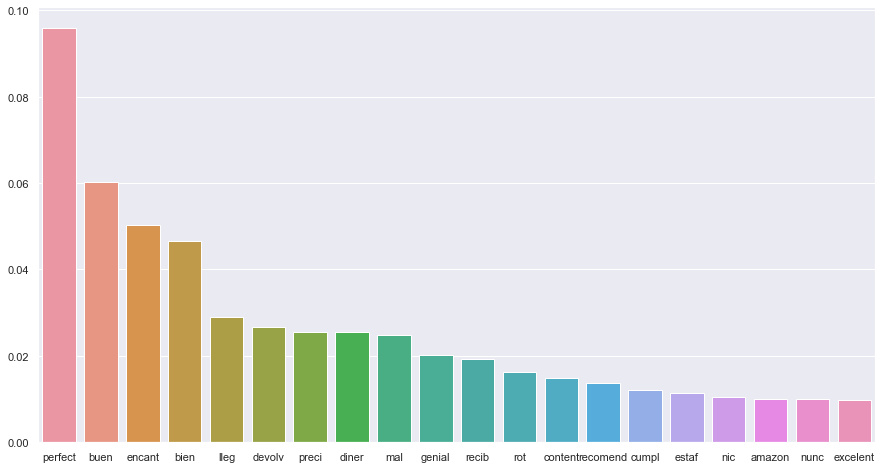

```python
# Le preguntamos la importancia de cada feature (cada palabra)
importances = rf.feature_importances_
# Tomamos la lista de palabras
all_words_train = cou_vec_train.get_feature_names()
columns = all_words_train

# Ordenamos por importnacia y tomamos las 20 primeras
indices = np.argsort(importances)[::-1]
indices = indices[:20]
selected_columns = [columns[i] for i in indices]
selected_importances = importances[indices]

# Por ultimo graficamos
plt.figure(figsize = (15,8))
sns.barplot(selected_columns, selected_importances)
plt.show()
```

### Parte C: Investigación.

Se estuvo leyendo articulos donde para lemmatizar en español se utiliza la librería "SpaCy". Estaría bueno aplicarla a que la lemmatización es un poco más sutil que el stemmizador para recortar las palabras.

Además convertir el problema en uno binario mejoraría un poco el rendimiento del modelo ya que como vimos, performa mejor para las negativas que para las positivas. Así que si juntamos esas críticas en una categoría mejoraría aunque sea muy poco el accuracy. Además estaría bueno probar eliminar ciertas palabras comunes a las 3 críticas como "bien", "calidad", etc que se crean que son comunes de utilizar en cualquier tipo de crítica de los vectores para mejorar el performance del modelo.

También se podrían probar otros modelos que quizas sean más especializados para nlp. Por ejemplo, el SVM (ref: https://www.lexalytics.com/lexablog/machine-learning-natural-language-processing) que procedemos a probar rápidamente abajo.

```python
from sklearn.svm import LinearSVC

svc = LinearSVC(C = 1)
svc.fit(X_train,y_train)
svc.score(X_test,y_test)
```

```
0.2582
```

Vemos que performa mejor que el modelo benchmark así que andaríamos en buen camino si usamos este modelo.